# práctica 4

## AUTOETS para 'eliminar' el efecto provocado por el COVID.

```python
# Creamos un horizonte de predicción. Como hemos cortado en febrero, queremos predecir hasta
# julio de 2021, que es cuando acaba el efecto covid: esto son 5 períodos:
fh = np.arange(1, 6)
mat_ficticio = AutoETS(auto= True,
                           sp = 4,
                           n_jobs=1)
```

```python
mat_ficticio.fit(y_train)
```

```
AutoETS(auto=True, n_jobs=1, sp=4)
```

```python
mat_pred = mat_ficticio.predict(fh)
print(mat_pred)
```

```
2019-09    89056.925135
2019-10    94951.659045
2019-11    99067.327756
2019-12    85901.107667
2020-01    89056.925135
Freq: M, dtype: float64
```

Vemos que las predicciones no son del todo buenas, pero vamos a quedárnoslas, porque cuando hicimos la prueba de predecir sin tener el período covid en absoluto nos quedamos muy alejados de la realidad, por encima. Por lo tanto así esperamos que las predicciones sean más realistas.

```
(<Figure size 1152x288 with 1 Axes>, <AxesSubplot:ylabel='matriculaciones'>)
```

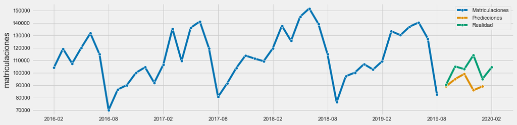

```python
plot_series(y_train, mat_pred, y_test,
            labels= ["Matriculaciones", 'Predicciones', 'Realidad'],)
```

```python
# Veamos como ha sacado el modelo:
print(mat_ficticio.summary())
```

```
                                 ETS Results
==============================================================================
Dep. Variable:        matriculaciones   No. Observations:                   43
Model:                       ETS(MNM)   Log Likelihood                -476.811
Date:                Sun, 19 Dec 2021   AIC                            969.621
Time:                        21:59:02   BIC                            983.711
Sample:                    02-29-2016   HQIC                           974.817
                         - 08-31-2019   Scale                            0.020
Covariance Type:               approx
======================================================================================
                         coef    std err          z      P>|z|      [0.025      0.975]
--------------------------------------------------------------------------------------
smoothing_level        0.8879      0.160      5.541      0.000       0.574       1.202
smoothing_seasonal  1.121e-05      0.312   3.59e-05      1.000      -0.611       0.611
initial_level       1.156e+05        nan        nan        nan         nan         nan
initial_seasonal.0     0.9379        nan        nan        nan         nan         nan
initial_seasonal.1     0.9047        nan        nan        nan         nan         nan
initial_seasonal.2     1.0433        nan        nan        nan         nan         nan
initial_seasonal.3     1.0000        nan        nan        nan         nan         nan
===================================================================================
Ljung-Box (Q):                       11.16   Jarque-Bera (JB):                 3.25
Prob(Q):                              0.19   Prob(JB):                         0.20
Heteroskedasticity (H):               1.26   Skew:                            -0.67
Prob(H) (two-sided):                  0.67   Kurtosis:                         3.06
===================================================================================

Warnings:
[1] Covariance matrix calculated using numerical (complex-step) differentiation.
```

```python
# Creamos el nuevo horizonte de predicción y predecimos:
mat_ficticio = mat.loc['2016-02': '2020-02']
fh = np.arange(1, 6) # desde que acaba el período, son 5 meses
df_auto = AutoETS(auto= True,
                  sp = 4,
                  n_jobs=1)
y = mat_ficticio['matriculaciones'].astype('float64').to_period('M')
df_auto.fit(y)
print(df_auto.summary())
```

```
                                 ETS Results
==============================================================================
Dep. Variable:        matriculaciones   No. Observations:                   49
Model:                       ETS(MNM)   Log Likelihood                -542.190
Date:                Sun, 19 Dec 2021   AIC                           1100.380
Time:                        21:59:03   BIC                           1115.514
Sample:                    02-29-2016   HQIC                          1106.122
                         - 02-29-2020   Scale                            0.019
Covariance Type:               approx
======================================================================================
                         coef    std err          z      P>|z|      [0.025      0.975]
--------------------------------------------------------------------------------------
smoothing_level        0.8278      0.117      7.084      0.000       0.599       1.057
smoothing_seasonal  1.722e-05        nan        nan        nan         nan         nan
initial_level       1.156e+05        nan        nan        nan         nan         nan
initial_seasonal.0     0.9349        nan        nan        nan         nan         nan
initial_seasonal.1     0.9229        nan        nan        nan         nan         nan
initial_seasonal.2     1.0361        nan        nan        nan         nan         nan
initial_seasonal.3     1.0000        nan        nan        nan         nan         nan
===================================================================================
Ljung-Box (Q):                       12.67   Jarque-Bera (JB):                 4.27
Prob(Q):                              0.12   Prob(JB):                         0.12
Heteroskedasticity (H):               0.82   Skew:                            -0.71
Prob(H) (two-sided):                  0.70   Kurtosis:                         3.29
===================================================================================

Warnings:
[1] Covariance matrix calculated using numerical (complex-step) differentiation.
```

```python
# Predicciones para el período covid: las usaremos como las reales, sustituyéndolo
# por los valores reales de esos meses:
df_pred = df_auto.predict(fh)
print(df_pred)
```

```
2020-03    108231.759770
2020-04     96402.294964
2020-05     97652.396091
2020-06    104457.446013
2020-07    108231.759770
Freq: M, dtype: float64
```

```python
df_int = mat
df_int.loc['2020-03-01':'2020-07-01',"matriculaciones"] = ['108231', ' 96402', '97652',
                                                     '104457', '  108231']
```

```python
# Comprobamos que los valores se han actualizado correctamente
df_int.loc['2020-03-01':'2020-07-01',"matriculaciones"]
```

```
periodos
2020-03-01      108231
2020-04-01       96402
2020-05-01       97652
2020-06-01      104457
2020-07-01      108231
Name: matriculaciones, dtype: object
```

```python
df_int['matriculaciones'] = df_int['matriculaciones'].astype(int )
```

Ya tenemos nuestro dataframe modificado, con los valores de marzo a julio de 2020 calculados a partir del AUTOETS.

## Usaremos el nuevo df para predecir noviembre y diciembre de 2021

```python
df_int['matriculaciones'] = df_int['matriculaciones'].astype(int)
df_int.index = pd.PeriodIndex(df_int.index, freq="M")
```

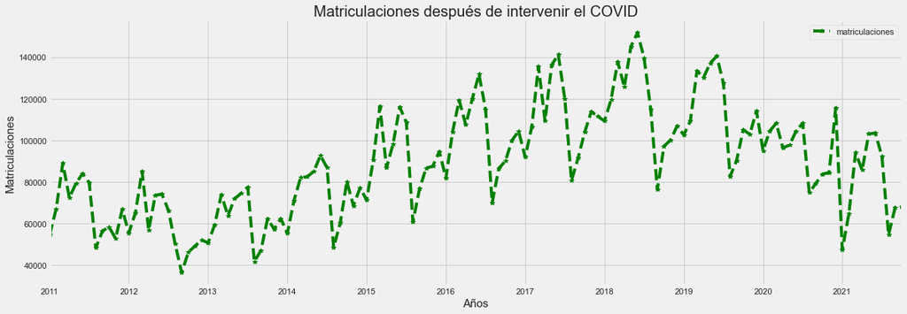

```python
# Visualizamos que el efecto del covid ha desaparecido:
fig2 = df_int.plot(marker='*', linestyle='--', color = 'green',
                  title = 'Matriculaciones después de intervenir el COVID')
fig2.set_ylabel('Matriculaciones', fontsize = 15)
fig2.set_xlabel('Años', fontsize = 15);
```

Igual que antes, tiene autocorrelación de 12 períodos. Usaremos el modelo ARIMA, que sabemos que es bueno cuando tratamos con series no estacionarias en media.

Como ya hemos dicho que no es una serie estacionaria, calculamos la transformación logarítmica para que sí lo sea y las predicciones sean mejores:

```python
# Creamos un DF auxiliar en escala logarítmica. Transformamos índice en freq Mensual
trans = LogTransformer()
log_df_int = trans.fit_transform(df_int)
log_df_int.index = pd.PeriodIndex(log_df_int.index, freq="M")
```

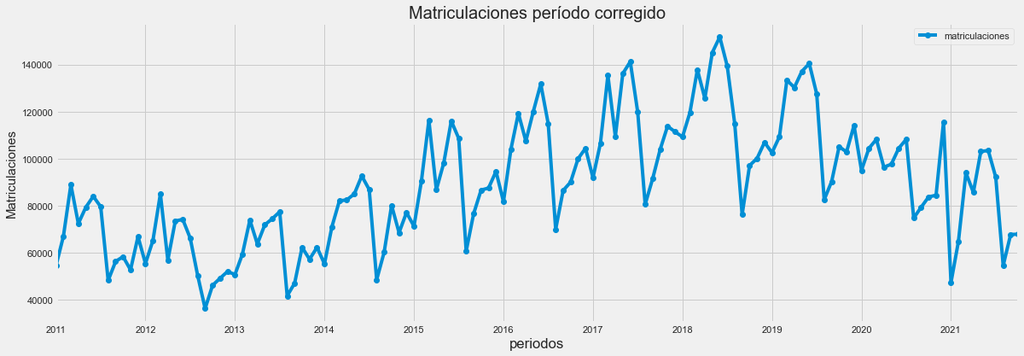

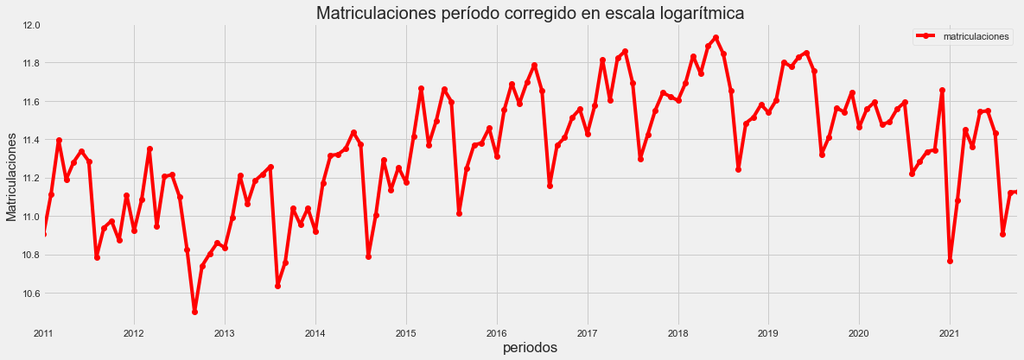

```python
# Representamos gráficamente la escala logarítimica.
# La comparamos con la serie original.
ax = df_int.plot(marker='o', linestyle='-')
ax.set_ylabel('Matriculaciones', fontsize = 15)
ax.set_title('Matriculaciones período corregido', fontsize = 20)

ax = log_df_int.plot(marker='o', linestyle='-', color = 'red')
ax.set_ylabel('Matriculaciones', fontsize = 15)
ax.set_title('Matriculaciones período corregido en escala logarítmica', fontsize = 20);
```

Autocorrelación de la serie en logaritmos:

```
(<Figure size 864x576 with 3 Axes>,
 array([<AxesSubplot:>, <AxesSubplot:title={'center':'Autocorrelation'}>,
        <AxesSubplot:title={'center':'Partial Autocorrelation'}>],
       dtype=object))
```

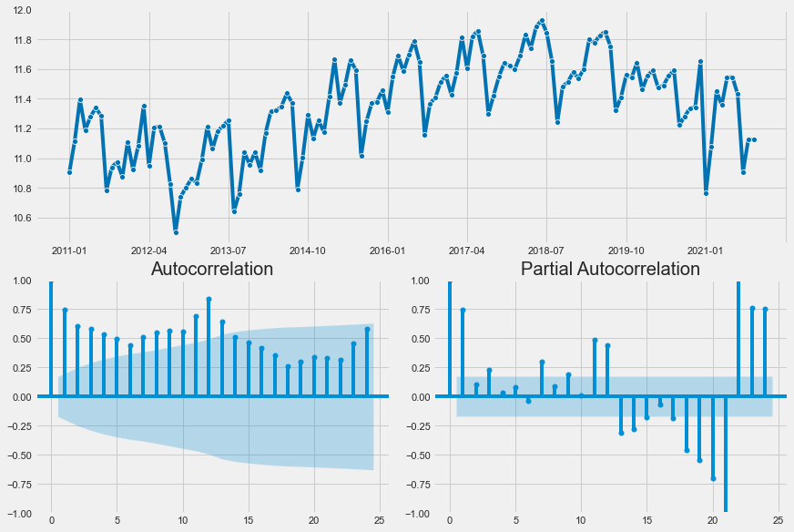

```python
plot_correlations(log_df_int)
```